# Examine Functional Form

2026-11-20

```r
## Set chunk options
knitr::opts_chunk$set(
  autodep = T, # Re-run cached chunks when objects they use from other chunks change
  # Some chunks cache objects; reset them if data changes
  cache.extra = tools::md5sum(c(
    list.files(here::here("Data"), recursive = T, full.names = T),
    here::here("Helper Functions", "Analysis Functions.R")
  ))
)


## Set seed
set.seed(87204)


## Load packages
library(here)
library(knitr)
library(kableExtra)
library(broom)
library(scales)
library(ggh4x)
library(mice)
library(marginaleffects)
library(tidyverse)
`%+%` <- paste0


## Load helper functions
source(here("Helper Functions", "Analysis Functions.R"))
source(here("Helper Functions", "DASS-21 Versus Norms.R"))


## Set global variables
study_period_labels <- c(
  "PIMH" = "First Study Period (2016-2019)",
  "PIH" = "Second Study Period (2019-2026)",
  "Combined" = "Combined"
)

severity_labels <- c(
  "5.5" = "Low (DASS = 5.5)",
  "8.5" = "Medium (DASS = 8.5)",
  "12"  = "High (DASS = 12)"
)

## Load data
# Non-imputed datasets ("_ni")
pimh_ni <- readRDS(here("Data", "PIMH - 2012-2019", "pimh_with_geo.rds"))
pih_ni <- readRDS(here("Data", "PIH - 2019-Current", "pih_with_geo.rds"))
all_ni <- bind_rows(pimh_ni, pih_ni)

# Completed ("_c")
pimh_c <- readRDS(here("Data", "PIMH - 2012-2019", "pimh_completed.rds"))
pih_c <- readRDS(here("Data", "PIH - 2019-Current", "pih_completed.rds"))
all_c <- readRDS(here("Data", "PIMH + PIH Combined", "all_completed.rds"))
```

# 1. Examine Functional Form

## 1.1. Functional Form, Visually

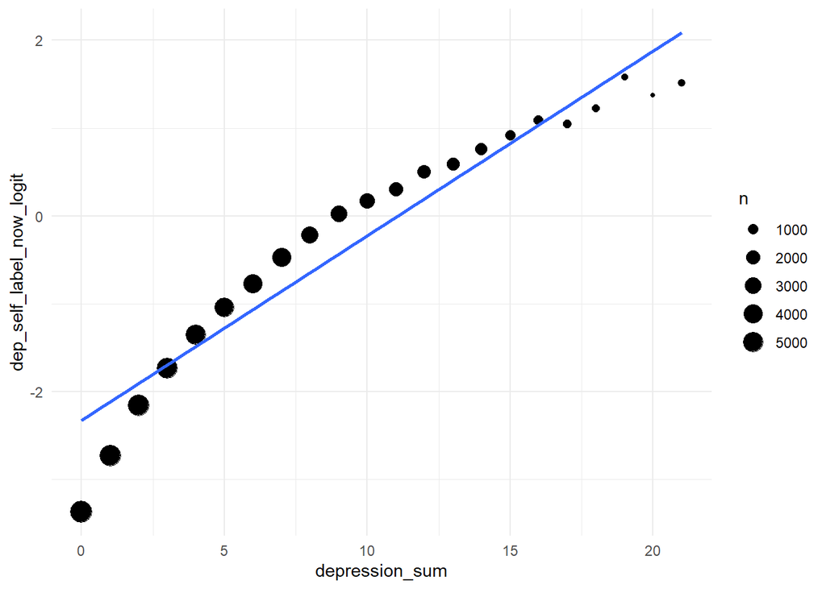

```r
## Self-labeling by symptom severity
all_ni %>%
  summarize(dep_self_label_now_p = mean(dep_self_label_now == 1), n = n(), .by = depression_sum) %>%
  mutate(dep_self_label_now_logit = qlogis(dep_self_label_now_p)) %>%
  ggplot(aes(x = depression_sum, y = dep_self_label_now_logit)) +
  geom_point(aes(size = n)) +
  geom_smooth(method = "lm", formula = "y ~ x", se = F) +
  theme_minimal()
```

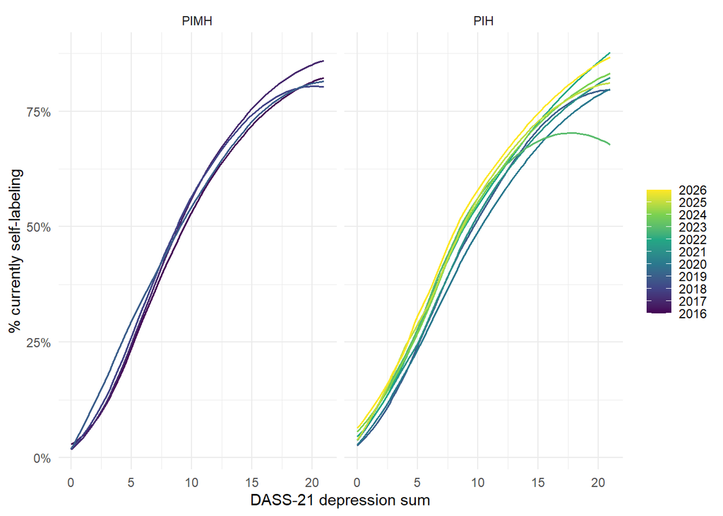

```r
## Self-labeling by symptom severity by year
all_ni %>%
  mutate(dataset = factor(dataset, levels = c("PIMH", "PIH"))) %>%
  ggplot(aes(x = depression_sum, y = as.numeric(dep_self_label_now), color = year, group = year)) +
  geom_smooth(method = "loess", formula = "y ~ x", se = F, linewidth = .7) +
  facet_wrap(~ dataset) +
  scale_color_viridis_c(breaks = 2016:2026) +
  scale_y_continuous(labels = scales::label_percent()) +
  labs(x = "DASS-21 depression sum", y = "% currently self-labeling", color = NULL) +
  theme_minimal()
```

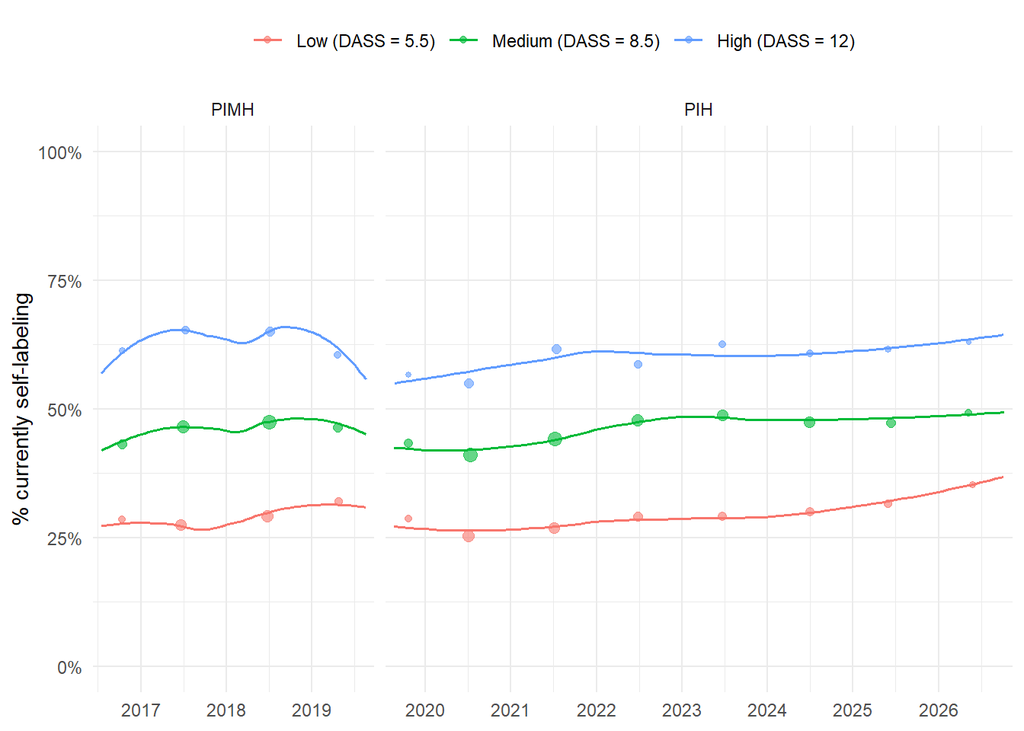

```r
## Self-labeling by year by symptom severity
# Create severity-banded data
banded <- all_ni %>%
  mutate(
    dataset = factor(dataset, levels = c("PIMH", "PIH")),
    severity = case_when(
      between(depression_sum, 5, 6)   ~ severity_labels[1],
      between(depression_sum, 7, 10)  ~ severity_labels[2],
      between(depression_sum, 11, 13) ~ severity_labels[3]
    ),
    severity = factor(severity, levels = severity_labels),
    dep_self_label_now = as.numeric(dep_self_label_now)
  ) %>%
  filter(!is.na(severity))

# Summarize by year
by_year <- banded %>%
  group_by(dataset, severity, year) %>%
  summarize(x = mean(decimal_year), p = mean(dep_self_label_now), n = n(), .groups = "drop")

# Plot
ggplot(banded, aes(x = decimal_year, y = dep_self_label_now, color = severity)) +
  geom_smooth(method = "loess", formula = "y ~ x", se = F, linewidth = .7) +
  geom_point(data = by_year, aes(x = x, y = p, size = n), alpha = 0.6) +
  facet_grid(. ~ dataset, scales = "free_x", space = "free_x") +
  scale_x_continuous(breaks = 2016:2026, expand = expansion(add = 0.1)) +
  scale_y_continuous(labels = scales::label_percent(), limits = c(0, 1)) +
  scale_size_area(max_size = 3, guide = "none") +
  labs(x = NULL, y = "% currently self-labeling", color = NULL) +
  theme_minimal() +
  theme(legend.position = "top")
```

The relationship between `depression_sum` and `dep_self_label_now` is clearly S-shaped, but non-linear.

Regarding the relationship between `decimal_year` and `dep_self_label_now`, we’re looking at a largely monotonous, perhaps linear relationship. The years stack up more cleanly at lower levels of depressive symptom severity than at higher levels; this may be reflected with a `decimal_year * dep_self_label_now` interaction term. There doesn’t look to be evidence for a non-linear transformation of year.

## 1.2. Functional Form, Tested

To simplify, we will examine the functional form across the entire dataset. Robustness checks will investigate it within PIMH and PIH samples separately. In these combined models, an additional covariate, `dataset`, is added to account for the discontinuity in outcomes observed above.

### 1.2.1. Relationship Between `dep_self_label_now` and `decimal_year_centered`

As shown above, descriptively, this relationship looks approximately linear. In this chunk, we test some alternative operationalizations to assess this statistically.

```r
# In PIMH
compare_models(
  pimh_c,
  list(
    "Linear" = dep_self_label_now ~ depression_sum + decimal_year_centered + age + race_recoded + gender + education,
    "Quadratic" = dep_self_label_now ~ depression_sum + poly(decimal_year_centered, 2) + age + race_recoded + gender + education,
    "Cubic" = dep_self_label_now ~ depression_sum + poly(decimal_year_centered, 3) + age + race_recoded + gender + education,
    "Log" = dep_self_label_now ~ depression_sum + log(decimal_year_centered + 6) + age + race_recoded + gender + education,
    "Exponentiated" = dep_self_label_now ~ depression_sum + exp(decimal_year_centered) + age + race_recoded + gender + education
  )
)
```

```
##
## Model fit (mean BIC across imputations; delta relative to Linear)
## # A tibble: 5 × 3
##   model         mean_bic delta_bic
##   <fct>            <dbl>     <dbl>
## 1 Linear          21094.     0
## 2 Quadratic       21104.     9.98
## 3 Cubic           21113.    19.7
## 4 Log             21094.     0.129
## 5 Exponentiated   21096.     2.83
##
## Point predictions (difference relative to Linear)
## # A tibble: 30 × 7
##    model      depression_sum decimal_year estimate conf.low conf.high difference
##    <fct>               <dbl>        <dbl>    <dbl>    <dbl>     <dbl>      <dbl>
```

[output cut: 50 more lines]

```r
# In PIH
compare_models(
  pih_c,
  list(
    "Linear" = dep_self_label_now ~ depression_sum + decimal_year_centered + age + race_recoded + gender + education,
    "Quadratic" = dep_self_label_now ~ depression_sum + poly(decimal_year_centered, 2) + age + race_recoded + gender + education,
    "Cubic" = dep_self_label_now ~ depression_sum + poly(decimal_year_centered, 3) + age + race_recoded + gender + education,
    "Log" = dep_self_label_now ~ depression_sum + log(decimal_year_centered + 6) + age + race_recoded + gender + education,
    "Exponentiated" = dep_self_label_now ~ depression_sum + exp(decimal_year_centered) + age + race_recoded + gender + education
  )
)
```

```
##
## Model fit (mean BIC across imputations; delta relative to Linear)
## # A tibble: 5 × 3
##   model         mean_bic delta_bic
##   <fct>            <dbl>     <dbl>
## 1 Linear          36809.      0
## 2 Quadratic       36817.      8.11
## 3 Cubic           36827.     17.6
## 4 Log             36807.     -2.01
## 5 Exponentiated   36835.     25.8
##
## Point predictions (difference relative to Linear)
## # A tibble: 30 × 7
##    model      depression_sum decimal_year estimate conf.low conf.high difference
##    <fct>               <dbl>        <dbl>    <dbl>    <dbl>     <dbl>      <dbl>
```

[output cut: 50 more lines]

```r
# In combined data
compare_models(
  all_c,
  list(
    "Linear" = dep_self_label_now ~ depression_sum + decimal_year_centered + age + race_recoded + gender + education + dataset,
    "Quadratic" = dep_self_label_now ~ depression_sum + poly(decimal_year_centered, 2) + age + race_recoded + gender + education + dataset,
    "Cubic" = dep_self_label_now ~ depression_sum + poly(decimal_year_centered, 3) + age + race_recoded + gender + education + dataset,
    "Log" = dep_self_label_now ~ depression_sum + log(decimal_year_centered + 6) + age + race_recoded + gender + education + dataset,
    "Exponentiated" = dep_self_label_now ~ depression_sum + exp(decimal_year_centered) + age + race_recoded + gender + education + dataset
  )
)
```

```
##
## Model fit (mean BIC across imputations; delta relative to Linear)
## # A tibble: 5 × 3
##   model         mean_bic delta_bic
##   <fct>            <dbl>     <dbl>
## 1 Linear          57909.      0
## 2 Quadratic       57917.      8.24
## 3 Cubic           57928.     19.1
## 4 Log             57911.      2.05
## 5 Exponentiated   57949.     39.9
##
## Point predictions (difference relative to Linear)
## # A tibble: 30 × 7
##    model      depression_sum decimal_year estimate conf.low conf.high difference
##    <fct>               <dbl>        <dbl>    <dbl>    <dbl>     <dbl>      <dbl>
```

[output cut: 50 more lines]

Indeed, all transformations fit worse, across PIMH, PIH, and combined datasets. (There is a slight improvement in BIC in the log model for PIH, but this is not indicated visually above, and results in negligible changes to point predictions and risk ratios). We conclude that this relationship is linear.

### 1.2.2. Relationship Between `dep_self_label_now` and `depression_sum`

As shown above, descriptively, this relationship is clearly “S-shaped” in all years, and non-linear. In this chunk, we test alternative operationalizations, then inspect them visually and by examining differences in predictions.

```r
# In PIMH
compare_models(
  pimh_c,
  list(
    "Linear" = dep_self_label_now ~ depression_sum + decimal_year_centered + age + race_recoded + gender + education,
    "Quadratic" = dep_self_label_now ~ poly(depression_sum, 2, raw = TRUE) + decimal_year_centered + age + race_recoded + gender + education,
    "Cubic" = dep_self_label_now ~ poly(depression_sum, 3, raw = TRUE) + decimal_year_centered + age + race_recoded + gender + education,
    "Log" = dep_self_label_now ~ log(depression_sum + 1) + decimal_year_centered + age + race_recoded + gender + education,
    "Exponentiated" = dep_self_label_now ~ exp(depression_sum) + decimal_year_centered + age + race_recoded + gender + education
  )
)
```

```
##
## Model fit (mean BIC across imputations; delta relative to Linear)
## # A tibble: 5 × 3
##   model         mean_bic delta_bic
##   <fct>            <dbl>     <dbl>
## 1 Linear          21094.        0
## 2 Quadratic       20691.     -403.
## 3 Cubic           20661.     -433.
## 4 Log             20679.     -415.
## 5 Exponentiated   27016.     5922.
##
## Point predictions (difference relative to Linear)
## # A tibble: 30 × 7
##    model      depression_sum decimal_year estimate conf.low conf.high difference
##    <fct>               <dbl>        <dbl>    <dbl>    <dbl>     <dbl>      <dbl>
```

[output cut: 50 more lines]

```r
# In PIH
compare_models(
  pih_c,
  list(
    "Linear" = dep_self_label_now ~ depression_sum + decimal_year_centered + age + race_recoded + gender + education,
    "Quadratic" = dep_self_label_now ~ poly(depression_sum, 2, raw = TRUE) + decimal_year_centered + age + race_recoded + gender + education,
    "Cubic" = dep_self_label_now ~ poly(depression_sum, 3, raw = TRUE) + decimal_year_centered + age + race_recoded + gender + education,
    "Log" = dep_self_label_now ~ log(depression_sum + 1) + decimal_year_centered + age + race_recoded + gender + education,
    "Exponentiated" = dep_self_label_now ~ exp(depression_sum) + decimal_year_centered + age + race_recoded + gender + education
  )
)
```

```
##
## Model fit (mean BIC across imputations; delta relative to Linear)
## # A tibble: 5 × 3
##   model         mean_bic delta_bic
##   <fct>            <dbl>     <dbl>
## 1 Linear          36809.        0
## 2 Quadratic       36352.     -458.
## 3 Cubic           36324.     -485.
## 4 Log             36429.     -381.
## 5 Exponentiated   44744.     7935.
##
## Point predictions (difference relative to Linear)
## # A tibble: 30 × 7
##    model      depression_sum decimal_year estimate conf.low conf.high difference
##    <fct>               <dbl>        <dbl>    <dbl>    <dbl>     <dbl>      <dbl>
```

[output cut: 50 more lines]

```r
# In combined data
compare_models(
  all_c,
  list(
    "Linear" = dep_self_label_now ~ depression_sum + decimal_year_centered + age + race_recoded + gender + education + dataset,
    "Quadratic" = dep_self_label_now ~ poly(depression_sum, 2, raw = TRUE) + decimal_year_centered + age + race_recoded + gender + education + dataset,
    "Cubic" = dep_self_label_now ~ poly(depression_sum, 3, raw = TRUE) + decimal_year_centered + age + race_recoded + gender + education + dataset,
    "Log" = dep_self_label_now ~ log(depression_sum + 1) + decimal_year_centered + age + race_recoded + gender + education + dataset,
    "Exponentiated" = dep_self_label_now ~ exp(depression_sum) + decimal_year_centered + age + race_recoded + gender + education + dataset
  )
)
```

```
##
## Model fit (mean BIC across imputations; delta relative to Linear)
## # A tibble: 5 × 3
##   model         mean_bic delta_bic
##   <fct>            <dbl>     <dbl>
## 1 Linear          57909.        0
## 2 Quadratic       57060.     -848.
## 3 Cubic           56995.     -913.
## 4 Log             57141.     -767.
## 5 Exponentiated   71764.    13856.
##
## Point predictions (difference relative to Linear)
## # A tibble: 30 × 7
##    model      depression_sum decimal_year estimate conf.low conf.high difference
##    <fct>               <dbl>        <dbl>    <dbl>    <dbl>     <dbl>      <dbl>
```

[output cut: 50 more lines]

These analyses support a cubic term in all three datasets (PIMH, PIH, combined). The addition of the cubic term slightly brings up the estimated rates of self-labeling at lower levels of symptom severity, but does not meaningfully change risk ratios by year.

### 1.2.3. Interaction Between `decimal_year_centered` and `depression_sum`

As shown above, descriptively, the relationship between year and self-labeling appears stronger at lower levels of symptom severity. This would be modeled with an interaction term; we test this here.

```r
covariates <- " + age + race_recoded + gender + education"

# In PIMH
compare_models(
  pimh_c,
  list(
    "Best-Fit" = "dep_self_label_now ~ poly(depression_sum, 3, raw = TRUE) + decimal_year_centered" %+% covariates,
    "Interaction" = "dep_self_label_now ~ poly(depression_sum, 3, raw = TRUE) * decimal_year_centered" %+% covariates
  )
)
```

```
##
## Model fit (mean BIC across imputations; delta relative to Best-Fit)
## # A tibble: 2 × 3
##   model       mean_bic delta_bic
##   <fct>          <dbl>     <dbl>
## 1 Best-Fit      20661.       0
## 2 Interaction   20684.      23.5
##
## Point predictions (difference relative to Best-Fit)
## # A tibble: 12 × 7
##    model      depression_sum decimal_year estimate conf.low conf.high difference
##    <fct>               <dbl>        <dbl>    <dbl>    <dbl>     <dbl>      <dbl>
##  1 Best-Fit              5.5         2016    0.260    0.242     0.278    0
##  2 Interacti…            5.5         2016    0.252    0.228     0.275   -0.00818
##  3 Best-Fit              5.5         2026    0.427    0.352     0.501    0
##  4 Interacti…            5.5         2026    0.466    0.359     0.574    0.0393
##  5 Best-Fit              8.5         2016    0.452    0.429     0.475    0
##  6 Interacti…            8.5         2016    0.456    0.427     0.485    0.00376
##  7 Best-Fit              8.5         2026    0.635    0.565     0.706    0
##  8 Interacti…            8.5         2026    0.623    0.528     0.717   -0.0128
##  9 Best-Fit             12           2016    0.611    0.587     0.635    0
## 10 Interacti…           12           2016    0.629    0.593     0.666    0.0180
## 11 Best-Fit             12           2026    0.769    0.714     0.824    0
## 12 Interacti…           12           2026    0.714    0.604     0.825   -0.0544
##
## Risk ratios per year (difference relative to Best-Fit)
## # A tibble: 6 × 6
##   model       depression_sum estimate conf.low conf.high difference
##   <fct>                <dbl>    <dbl>    <dbl>     <dbl>      <dbl>
## 1 Best-Fit               5.5     1.05    1.03       1.08    0
## 2 Interaction            5.5     1.07    1.03       1.11    0.0148
## 3 Best-Fit               8.5     1.04    1.02       1.06    0
## 4 Interaction            8.5     1.03    1.01       1.06   -0.00357
## 5 Best-Fit              12       1.03    1.01       1.04    0
## 6 Interaction           12       1.01    0.990      1.04   -0.0125
```

```r
# In PIH
compare_models(
  pih_c,
  list(
    "Best-Fit" = "dep_self_label_now ~ poly(depression_sum, 3, raw = TRUE) + decimal_year_centered" %+% covariates,
    "Interaction" = "dep_self_label_now ~ poly(depression_sum, 3, raw = TRUE) * decimal_year_centered" %+% covariates
  )
)
```

```
##
## Model fit (mean BIC across imputations; delta relative to Best-Fit)
## # A tibble: 2 × 3
##   model       mean_bic delta_bic
##   <fct>          <dbl>     <dbl>
## 1 Best-Fit      36324.       0
## 2 Interaction   36350.      25.9
##
## Point predictions (difference relative to Best-Fit)
## # A tibble: 12 × 7
##    model      depression_sum decimal_year estimate conf.low conf.high difference
##    <fct>               <dbl>        <dbl>    <dbl>    <dbl>     <dbl>      <dbl>
##  1 Best-Fit              5.5         2016    0.244    0.228     0.261    0
##  2 Interacti…            5.5         2016    0.239    0.217     0.261   -0.00554
##  3 Best-Fit              5.5         2026    0.327    0.315     0.339    0
##  4 Interacti…            5.5         2026    0.331    0.316     0.346    0.00338
##  5 Best-Fit              8.5         2016    0.408    0.387     0.429    0
##  6 Interacti…            8.5         2016    0.419    0.392     0.446    0.0110
##  7 Best-Fit              8.5         2026    0.508    0.494     0.521    0
##  8 Interacti…            8.5         2026    0.501    0.485     0.518   -0.00617
##  9 Best-Fit             12           2016    0.558    0.536     0.580    0
## 10 Interacti…           12           2016    0.584    0.547     0.622    0.0267
## 11 Best-Fit             12           2026    0.654    0.639     0.668    0
## 12 Interacti…           12           2026    0.639    0.618     0.661   -0.0141
##
## Risk ratios per year (difference relative to Best-Fit)
## # A tibble: 6 × 6
##   model       depression_sum estimate conf.low conf.high difference
##   <fct>                <dbl>    <dbl>    <dbl>     <dbl>      <dbl>
## 1 Best-Fit               5.5     1.03     1.02      1.04    0
## 2 Interaction            5.5     1.03     1.02      1.04    0.00323
## 3 Best-Fit               8.5     1.02     1.01      1.03    0
## 4 Interaction            8.5     1.02     1.01      1.03   -0.00368
## 5 Best-Fit              12       1.02     1.01      1.02    0
## 6 Interaction           12       1.01     1.00      1.02   -0.00640
```

```r
# In combined data, allowing the severity curve to differ by study period, so the interaction is not confounded with the change between study periods
compare_models(
  all_c,
  list(
    "Best-Fit" = "dep_self_label_now ~ poly(depression_sum, 3, raw = TRUE) + decimal_year_centered" %+% covariates %+% " + dataset + poly(depression_sum, 3, raw = TRUE):dataset",
    "Interaction" = "dep_self_label_now ~ poly(depression_sum, 3, raw = TRUE) * decimal_year_centered" %+% covariates %+% " + dataset + poly(depression_sum, 3, raw = TRUE):dataset"
  )
)
```

```
##
## Model fit (mean BIC across imputations; delta relative to Best-Fit)
## # A tibble: 2 × 3
##   model       mean_bic delta_bic
##   <fct>          <dbl>     <dbl>
## 1 Best-Fit      56964.       0
## 2 Interaction   56989.      24.7
##
## Point predictions (difference relative to Best-Fit)
## # A tibble: 12 × 7
##    model      depression_sum decimal_year estimate conf.low conf.high difference
##    <fct>               <dbl>        <dbl>    <dbl>    <dbl>     <dbl>      <dbl>
##  1 Best-Fit              5.5         2016    0.252    0.240     0.264    0
##  2 Interacti…            5.5         2016    0.246    0.231     0.262   -0.00525
##  3 Best-Fit              5.5         2026    0.345    0.330     0.361    0
##  4 Interacti…            5.5         2026    0.352    0.332     0.373    0.00672
##  5 Best-Fit              8.5         2016    0.426    0.411     0.441    0
##  6 Interacti…            8.5         2016    0.434    0.414     0.453    0.00727
##  7 Best-Fit              8.5         2026    0.537    0.521     0.553    0
##  8 Interacti…            8.5         2026    0.529    0.508     0.550   -0.00787
##  9 Best-Fit             12           2016    0.579    0.563     0.596    0
## 10 Interacti…           12           2016    0.600    0.573     0.627    0.0209
## 11 Best-Fit             12           2026    0.682    0.667     0.697    0
## 12 Interacti…           12           2026    0.662    0.636     0.689   -0.0202
##
## Risk ratios per year (difference relative to Best-Fit)
## # A tibble: 6 × 6
##   model       depression_sum estimate conf.low conf.high difference
##   <fct>                <dbl>    <dbl>    <dbl>     <dbl>      <dbl>
## 1 Best-Fit               5.5     1.03     1.02      1.04    0
## 2 Interaction            5.5     1.04     1.02      1.05    0.00415
## 3 Best-Fit               8.5     1.02     1.02      1.03    0
## 4 Interaction            8.5     1.02     1.01      1.03   -0.00321
## 5 Best-Fit              12       1.02     1.01      1.02    0
## 6 Interaction           12       1.01     1.00      1.02   -0.00654
```

The interaction term does not improve model fit. The relationship between `depression_sum` and `dep_self_label_now` does not appear to depend on `decimal_year_centered`. The weaker relationship at higher levels of symptom severity observed above is probably just a loss in precision due to smaller sample size.

These analyses pretty conclusively support a best-fit model of `dep_self_label_now ~ poly(depression_sum, 3, raw = TRUE) + decimal_year_centered + age + race_recoded + gender + education`. This section does not examine the functional form of covariates to the outcome; for the sake of parsimony in primary analyses, this is assumed to be linear. These relationships are investigated further in secondary analyses.